# Week 9 Quiz

[If you have a negative value then just choose the correct magnitude - i.e. the value as a positive number]

- 1.93
- 0.59
- 2.57
- 0.10
- 1.82

**Question 10**

A hypothesis test to test if one mean is greater than the other (1-tailed probability) was conducted, with $n_1 = 24$ and $n_2 = 26$ and

$t = \frac{\bar{x}_1 − \bar{x}_2 − 0}{SE(\bar{x}_1 − \bar{x}_2)} = 1.27$

Select the correct P-value range, using $df = n_1 + n_2 -2$.

- $P-value > 0.01$
- $P-value > 0.2$
- $0.05 < P-value<0.1$
- $P-value > 0.1$
- $P-value < 0.05$

**Question 11**

An experiment was conducted to test the ability of rats to navigate a maze, as measured by the time it takes rats to find food at the end of the maze. The average maze completion time (in minutes) for 25 male rats was 64.2 minutes and for 28 female rats the average completion time was 59.4 minutes Is the difference in mean completion times significant? Using a calculated test statistic value of $t = 4.72$ and $P-value < 0.010$, choose the most correct conclusion (use $\alpha = 0.05$).

- Fail to reject $H_0$ since $P-value < 0.05$ – there is evidence that the mean completion time for male rats is longer than that for females
- Reject $H_a$ since $P-value < 0.05$ – there is insufficient evidence that the mean completion time for male and female rats is different
- Reject $H_0$ since the $P-value < 0.05$ – there appears to be a significant difference in the mean completion time for male and female rats
- Reject $H_0$ since $P-value > 0.05$ – there appears to be no significant difference in the mean completion time for male and female rats
- Fail to reject $H_0 since P-value > 0.05$ – there appears to be no significant difference in the mean completion time for male and female rats

**Question 12**

The average hours of pain relief provided by five different pain relief drugs are to be compared. Patients with post-surgery pain were randomly assigned to one of the drugs and the number of hours of pain relief recorded. Ten patients were assigned to take each drug. Choose the appropriate null and alternative hypotheses.

- $H_a: \mu1 \ne \mu2 \ne \mu3 \ne \mu4 \ne \mu5$ (all five of the groups’ averages differ)
- $H_a$: At least 2 of the drugs provide significantly different average pain relief
- $H_0: \mu1 = \mu2 = \mu3 = \mu4 = \mu5$ (all drugs have the same average pain relief)
- $H_0$: The average pain relief for drug 1 is significantly lower than all other drugs.

**Question 13**

Random samples of adults from three different suburbs were selected, and their weights recorded. The summary statistics and SPSS ANOVA output to test whether the average weights were different between any of the suburbs is shown.

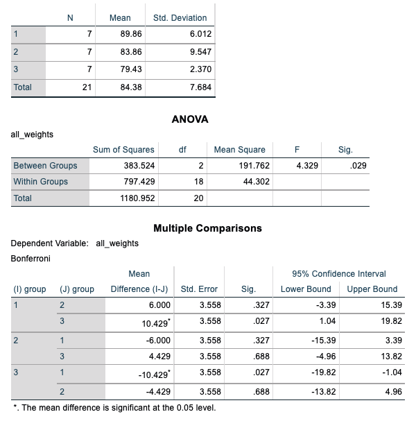

ANOVA Data

Which option shows the test statistic value and the P-value for this test?

- F = 4.329 and P-value = 0.058
- F = 4.329 and P-value = 0.0145
- t = 3.558 and P-value = 0.327
- F = 4.329 and P-value = 0.029
- F = 0.629 and P-value = 0.545

**Question 14**

Random samples of 5 students from four different prac groups were selected, and their scores for an assessment task (out of 80) recorded. Do any of the groups’ means differ significantly? Use SPSS to perform the ANOVA test then select the option that shows the test statistic value and P-value.

```r
  knitr::kable(Q14, "pipe")
```

| Group.1 | Group.2 | Group.3 | Group.4 |
| --- | --- | --- | --- |
| 60 | 51 | 60 | 65 |
| 56 | 50 | 59 | 67 |
| 57 | 53 | 64 | 66 |
| 58 | 60 | 59 | 59 |
| 50 | 59 | 57 | 69 |

- F = 14.100 and P-value = 0.002
- F = 7.833 and P-value = 0.002
- t = 9.358 and P-value = 0.000
- F = 10.470 and P-value = 0.000
- F = 7.833 and P-value = 0.001

**Question 15**

An experiment involved hand washing with four different soaps to see what effect the soaps might have on bacteria colonies. The ANOVA table is shown below.

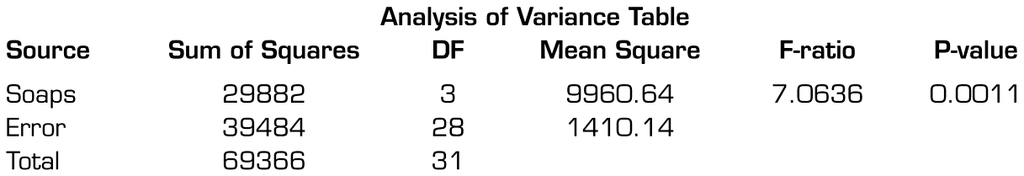

ANOVA Data

What are the conclusions you can reach based on the test (use $\alpha = 0.05$)?

[Select all that apply]

- There are no statistically significant differences between mean bacteria colonies for any of the soaps.
- Since $p-value > \alpha$, we fail to reject $H_0$.
- The average bacteria colonies between at least two of the soaps are significantly different.
- Since $p-value < \alpha$, we reject $H_0$.
- It would be appropriate to perform Bonferroni multiple comparisons to determine which soaps result in significantly different mean bacteria colonies.

**Question 16**

Random samples of students from three different prac groups were selected, and their scores for an assessment task (out of 80) recorded. The summary statistics and SPSS ANOVA output to test whether the average scores were different between any of the prac groups is shown.

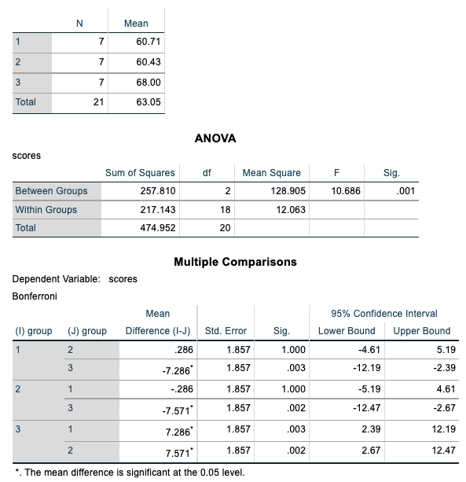

ANOVA Data

Which option gives the most accurate summary of the Bonferroni Multiple Comparisons, using $\alpha = 0.05$?

- The mean for group 3 is significantly higher than the mean for group 1, which is significantly higher than the mean for group 2.
- The mean for group 1 is significantly higher than the mean for group 2.
- All of the groups’ means are significantly different to each other.
- The mean for group 3 is significantly higher than the means for groups 1 and 2.
- None of the groups’ means are significantly different to each other.